# Australian Beer Sales from 1956 to 1994

#### Section 5: Forecasting

In order to forecast future values, the model must first be applied to the original data set before differencing. Then, a prediction will be taken using the R command `predict()` and these values are plotted in *Figure 16* below. It can be seen based on the 95% confidence interval, calculated by $\text{Predicted Value} \pm 1.96\times\text{Standard Error}$, that these values have a large potential of movement. Despite this, the values will most likely not stray far from the predictions or those of the previous years.

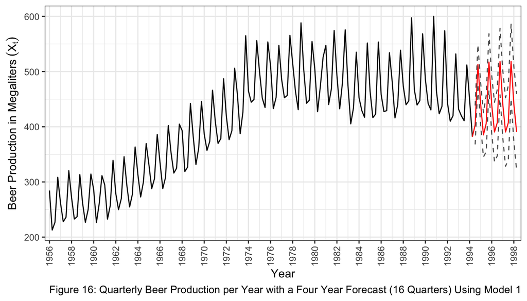

#### Conclusion

Contrary to the expectation that the downwards trend will continue, the forecasts indicate that there will be a slight rise in production over the next four years. The 95% confidence interval suggests that there is a possibility for a continued decline, consistent with slight downwards trend after 1992. This is what I would consider the most likely scenario as well. The model chosen to predict this data is contained below the conclusion.
$$(1-B)(1-B^4)X_t = (1 + -1.955B + 1.381B^2 - 0.405B^3)(1 - 1.864B^4 +
0.864^8)Z_t$$

#### References

Rob Hyndman and Yangzhuoran Yang (2018). tsdl: Time Series Data Library. v0.1.0.  
https://pkg.yangzhuoranyang.com/tsdl/  
Australian Bureau of Statistics, Quarterly beer production, 1956-1994  
David Stoffer (2021). astsa: Applied Statistical Time Series Analysis. v1.14  
https://github.com/nickpoison/astsa/  
Brian Ripley, Bill Venables, Douglas M. Bates, Kurt Hornik, Albrecht Gebhardt, and David Firth (2022). MASS: Support Functions and Datasets for Venables and Ripley’s MASS. v7.3-55.  
http://www.stats.ox.ac.uk/pub/MASS4/  
Hadley Wickham and RStudio (2021). tidyverse: Easily Install and Load the ‘Tidyverse’. v1.3.1  
https://tidyverse.tidyverse.org  
Jonathan Berrisch (2018). UnitCircle: Check if Roots of a Polynomial Lie Outside of the Unit Circle. v0.1.3.  
https://github.com/BerriJ/UnitCircle  
Yeuk Yu Lee and Samuel Ventura (2017). lindia: Automated Linear Regression Diagnostic. v0.9  
https://github.com/yeukyul/lindia  
Rob Hyndman, George Athanasopoulos, Christoph Bergmeir, G. Caceres, L. Chhay, M. O’Hara-Wild, F. Petropoulos, S. Razbash, E. Wang, F. Yasmeen, R Core Team, R. Ihaka, D. Reid, D. Shaub, Y. Tang, and Z. Zhou (2022). forecast: Forecasting Functions for Time Series and Linear Models. v8.16.  
https://pkg.robjhyndman.com/forecast/  
Baptiste Auguie (2017). gridExtra: Miscellaneous Functions for “Grid” Graphics. v2.3  
https://CRAN.R-project.org/package=gridExtra

#### Appendix

```r
knitr::opts_chunk$set(echo = TRUE)
library(tsdl)
library(astsa)
library(MASS)
library(tidyverse)
library(UnitCircle)
library(lindia)
library(forecast)
library(gridExtra)
# SELECTING THE DATA FROM THE TSDL
beerdata <- tsdl[[99]]
beerdata.ts <- ts(beerdata, frequency = 4, start = c(1956, 1))
# CONVERTING THE TIME SERIES INTO A DATA FRAME AND PLOTTING WITH GGPLOT
beerdf <- data.frame(Y=as.matrix(beerdata.ts), date=time(beerdata.ts))
ggplot(beerdf, aes(x = date, y = Y)) + # PLOTTING THE DATA USING GGPLOT
  geom_line() +                        # AS A LINE
  scale_x_continuous(breaks = scales::pretty_breaks((1994.25 - 1956)/2),
                     expand = c(.01,0)) +
  geom_line(aes(x = date, y = mean(Y)), col = 'red') +
  labs(x = "Year",
       y = expression("Beer Production in Megaliters" ~ (X[t])),
       caption = "Figure 1: Quarterly Beer Production per Year") +
  ggplot2::theme_bw() +
  theme(axis.text.x = element_text(angle = 90, vjust = 0.5),
        plot.caption = element_text(size = 10))
# MAKING THE DATA STATIONARY
beerdata.d1 <- diff(beerdata.ts, 1) # DIFFERENCING BY 1
beerdf.d1 <- data.frame(Y=as.matrix(beerdata.d1), date=time(beerdata.d1))
ggplot(beerdf.d1, aes(x = date, y = Y)) + # PLOTTING THE DATA
  geom_line() +                           # AS A LINE
  geom_abline(aes(slope = 0, intercept = 0)) +
  scale_x_continuous(breaks = scales::pretty_breaks((1994.25 - 1956)/2),
                     expand = c(.01,0)) +
  geom_line(aes(x = date, y = mean(Y)), col = 'red') +
  labs(x = "Year",
       y = expression(nabla ~ X[t]),
       caption = expression("Figure 2: " ~ X[t] ~ " Differenced at Lag 1")) +
  ggplot2::theme_bw() +
  theme(axis.text.x = element_text(angle = 90, vjust = 0.5),
        plot.caption = element_text(size = 10))
beerdata.d14 <- diff(beerdata.d1, 4) # DIFFERENCING BY 4
beerdf.d14 <- data.frame(Y=as.matrix(beerdata.d14), date=time(beerdata.d14))
ggplot(beerdf.d14, aes(x = date, y = Y)) + # PLOTTING THE DATA
  geom_line() +                            # AS A LINE
  scale_x_continuous(breaks = scales::pretty_breaks((1994.25 - 1956)/2),
                     expand = c(.01,0)) +
  geom_abline(aes(slope = 0, intercept = 0)) +
  geom_line(aes(x = date, y = mean(Y)), col = 'red') +
  labs(x = "Year",
       y = expression(nabla^4 ~ nabla ~ X[t]),
       caption = expression("Figure 3: " ~ X[t] ~ " Differenced at Lags 1 and 4")) +
  ggplot2::theme_bw() +
  theme(axis.text.x = element_text(angle = 90, vjust = 0.5),
        plot.caption = element_text(size = 10))
ggAcf(beerdata.d14) + # PLOTTING THE ACF USING GGPLOT
  ggplot2::theme_bw() +
  labs(x = "Lag",
       y = 'ACF',
       caption = expression("Figure 4: Autocorrelation Function for" ~ nabla^4 ~ nabla ~ X[t])) +
  theme(plot.title = element_blank(),
        plot.caption = element_text(size = 10))
ggPacf(beerdata.d14) + # PLOTTING THE PACF USING GGPLOT
  ggplot2::theme_bw() +
  labs(x = "Lag",
       y = 'PACF',
       caption = expression("Figure 5: Partial Autocorrelation Function for" ~ nabla^4 ~ nabla ~ X[t])) +
  theme(plot.title = element_blank(),
        plot.caption = element_text(size = 10))
# FITTING A MODEL
# THIS WAS USED TO FIT AN AIC(c) MODEL
df <- expand.grid(p=0:4, q=0:4, P=0:4, Q=0:4)
df <- cbind(df, AICc=NA)

# AICC TESTING
for (i in 1:nrow(df)) {
  try(arima.obj <- arima(beerdata.d14, order=c(df$p[i], 1, df$q[i]),
  seasonal=list(order=c(df$P[i], 1, df$Q[i]), period=4),
  method="ML"))
  if (!is.null(arima.obj)) {
    df$AICc[i] <- AICc(arima.obj)
  }
}
# FITTING THE FIRST MODEL
fit1.arima = arima(beerdata.d14, order = c(0, 1, 3),
            seasonal = list(order = c(0, 1, 2), period = 4),
            method = "ML")
# FITTING VALUES TO THE MODEL
ma.coef1 <- fit1.arima$coef[1:3]
sma.coef1 <- fit1.arima$coef[4:5]

# CHECKING THE ROOTS
uc.check(c(1, ma.coef1), plot_output = FALSE)
uc.check(c(1, sma.coef1), plot_output = FALSE)
# DIAGNOSTIC TESTING
res1 <- residuals(fit1.arima)

# PLOTTING FITTED RESIDUALS
res1df <- data.frame(Y=as.matrix(res1), date=time(res1))
ggplot(res1df, aes(x = date, y = Y)) +
  geom_line() +
  scale_x_continuous(breaks = scales::pretty_breaks((1994.25 - 1956)/2),
                     expand = c(.01,0)) +
  geom_abline(aes(slope = 0, intercept = 0)) +
  geom_line(aes(x = date, y = mean(Y)), col = 'red') +
  labs(x = "Year",
       y = expression(nabla^4 ~ nabla ~ X[t]),
       caption = expression("Figure 6: Fitted Residuals of Model 1")) +
  ggplot2::theme_bw() +
  theme(axis.text.x = element_text(angle = 90, vjust = 0.5),
        plot.caption = element_text(size = 10))
res1ACF <- ggAcf(res1) + # ACF OF RESIDUALS OF MODEL 1
  ggplot2::theme_bw() +
  labs(x = "Lag",
       y = 'PACF',
       caption = expression("Figure 7: Autocorrelation Function of the Residuals of Model 1")) +
  theme(plot.title = element_blank(),
        plot.caption = element_text(size = 10))
res1PACF <- ggPacf(res1) + # PACF OF RESIDUALS OF MODEL 1
  ggplot2::theme_bw() +
  labs(x = "Lag",
       y = 'PACF',
       caption = expression("Figure 8: Partial Autocorrelation Function of the Residuals of Model 1")) +
  theme(plot.title = element_blank(),
        plot.caption = element_text(size = 10))
grid.arrange(res1ACF, res1PACF)
# TEST FOR INDEPENDENCE OF RESIDUALS
Box.test(res1, lag = 12, type = c("Box-Pierce"), fitdf = 5) # BOX PIERCE
Box.test(res1, lag = 12, type = c("Ljung-Box"), fitdf = 5) # BOX LJUNG
# NORMALITY ASSUMPTION
shapiro.test(res1)
# HISTOGRAM AND QQ-PLOT
hist1 <- gghistogram(res1, add.normal = TRUE) +
  ggplot2::theme_bw() +
  labs(x = "Residuals",
       y = "Frequency",
       caption = "Figure 9: Histogram of the Residuals of Model 1") +
  theme(plot.title = element_blank(),
        plot.caption = element_text(size = 10))

n = 1:length(res1)
res1.fit = lm(res1 ~ n)
qq1 <- gg_qqplot(res1.fit) +
  ggplot2::theme_bw() +
  labs(y = "Sample Quantile",
       caption = "Figure 10: Normal-QQ Plot of the Residuals of Model 1") +
  theme(plot.title = element_blank(),
        plot.caption = element_text(size = 10))

grid.arrange(hist1, qq1, ncol = 2)
fit2.arima = arima(beerdata.d14, order = c(0, 1, 3), # MODEL 2
            seasonal = list(order = c(1, 1, 3), period = 4),
            method = "ML")
# FITTING VALUES TO THE MODEL
ma.coef2 <- fit2.arima$coef[1:3]
sar.coef2 <- fit2.arima$coef[4]
sma.coef2 <- fit2.arima$coef[5:7]

# CHECKING THE ROOTS
uc.check(c(1, ma.coef2), plot_output = FALSE)
uc.check(c(1, sar.coef2), plot_output = FALSE)
uc.check(c(1, sma.coef2), plot_output = FALSE)
#DIAGNOSTIC TESTING
res2 <- residuals(fit2.arima)

# PLOTTING FITTED RESIDUALS
res2df <- data.frame(Y=as.matrix(res2), date=time(res2))
ggplot(res2df, aes(x = date, y = Y)) +
  geom_line() +
  scale_x_continuous(breaks = scales::pretty_breaks((1994.25 - 1956)/2),
                     expand = c(.01,0)) +
  geom_abline(aes(slope = 0, intercept = 0)) +
  geom_line(aes(x = date, y = mean(Y)), col = 'red') +
  labs(x = "Year",
       y = expression(nabla^4 ~ nabla ~ X[t]),
       caption = expression("Figure 11: Fitted Residuals of Model 2")) +
  ggplot2::theme_bw() +
  theme(axis.text.x = element_text(angle = 90, vjust = 0.5),
        plot.caption = element_text(size = 10))

res2ACF <- ggAcf(res2) + # ACF OF RESIDUALS OF MODEL 2
  ggplot2::theme_bw() +
  labs(x = "Lag",
       y = 'PACF',
       caption = expression("Figure 12: Autocorrelation Function of the Residuals of Model 2")) +
  theme(plot.title = element_blank(),
        plot.caption = element_text(size = 10))
res2PACF <- ggPacf(res2) + # PACF OF RESIDUALS OF MODEL 2
  ggplot2::theme_bw() +
  labs(x = "Lag",
       y = 'PACF',
       caption = expression("Figure 13: Partial Autocorrelation Function of the Residuals of Model 2")) +
  theme(plot.title = element_blank(),
        plot.caption = element_text(size = 10))
grid.arrange(res2ACF, res2PACF) # PLOTTING AS A GRID
Box.test(res2, lag = 12, type = c("Box-Pierce"), fitdf = 6) # BOX PIERCE
Box.test(res2, lag = 12, type = c("Ljung-Box"), fitdf = 6) # LJUNG BOX
shapiro.test(res2)
# HISTOGRAM AND QQ-PLOT
hist2 <- gghistogram(res2, add.normal = TRUE) +
  ggplot2::theme_bw() +
  labs(x = "Residuals",
       y = "Frequency",
       caption = "Figure 14: Histogram of the Residuals of Model 2") +
  theme(plot.title = element_blank(),
        plot.caption = element_text(size = 10))

n = 1:length(res2)
res2.fit = lm(res2 ~ n)
qq2 <- gg_qqplot(res2.fit) +
  ggplot2::theme_bw() +
  labs(y = "Sample Quantile",
       caption = "Figure 15: Normal-QQ Plot of the Residuals of Model 2") +
  theme(plot.title = element_blank(),
        plot.caption = element_text(size = 10))

grid.arrange(hist2, qq1, ncol = 2)
fit1.orig <- arima(beerdata.ts, order = c(0, 0, 3),
            seasonal = list(order = c(0, 1, 2), period = 4),
            method = "ML") # FITTING THE MODEL TO ORIGINAL DATA
pred1 <- predict(fit1.orig, n.ahead=16) # FORECASTING n = 16
pred1 <- data.frame(pred1, "date" = tail(beerdf$date, 16) + 4)
newrow <- data.frame(pred = beerdata.ts[154], se = 0, date = 1994.25)
pred1 <- rbind(newrow, pred1)

ggplot() + # PLOTTING THE FORECASTED DATA
  geom_line(beerdf, mapping = aes(x = date, y = Y)) + # ORIGINAL
  scale_x_continuous(breaks = scales::pretty_breaks((1998.25 - 1956)/2),
                     expand = c(.01,0)) +
  geom_line(pred1, mapping = aes(x = date, y = pred),
             color = 'red') + # FORECAST
  geom_line(pred1[2:17,], mapping = aes(x = date, y = pred + 1.96*se),
            linetype = "dashed", col = "gray38") + # 95% CONFIDENCE INCREASE
  geom_line(pred1[2:17,], mapping = aes(x = date, y = pred - 1.96*se),
              linetype = "dashed", col = "gray38") + # 95% CONFIDENCE DECREASE
  labs(x = "Year",
       y = expression("Beer Production in Megaliters" ~ (X[t])),
       caption = "Figure 16: Quarterly Beer Production per Year with a Four Year Forecast (16 Quarters) Using Model 1") +
  ggplot2::theme_bw() +
  theme(axis.text.x = element_text(angle = 90, vjust = 0.5),
        plot.caption = element_text(size = 10))
```